# Product Sales - Time Series Analysis by ContextBase

John Akwei, ECMp ERMp Data Scientist

October 12, 2015

[figure not shown]

# Synopsis

This document is a time series analysis of the Data using R to help answer the questions below:

1. Are there some products and product groups where a certain type of marketing can be seen to work?
2. Are there some products and product groups where it is impossible to see any marketing effect?
3. Does seasonality need to be considered?
4. Does trend over time need to be considered?
5. Can the effect of marketing only be seen in the month during which the marketing occurred, or is there a follow on effect where marketing influences sales in subsequent months?
6. Are there products where the data is just insufficient to draw any conclusions?

```r
library(dplyr)
library(ggplot2)
ProductSales <- read.csv("new_clean_data.csv")
# head(ProductSales, 2)
```

### Data Categories:

```r
names(ProductSales)
```

```
##  [1] "sales_month"      "item_code"        "vendor_code"
##  [4] "launch_month"     "unit_price"       "department_name"
##  [7] "category_name"    "subcategory_name" "sales_velocity"
## [10] "sales_unit"       "promotion_type"   "promotion"
```

### Time Series of Promotion Type:

```r
promotiontype <- unique(ProductSales$promotion_type)
promotiontype
```

```
## [1] no_promotion        In-Store Promotion  Catalogue Promotion
## [4] In-store Promotion
## 4 Levels: Catalogue Promotion In-store Promotion ... no_promotion
```

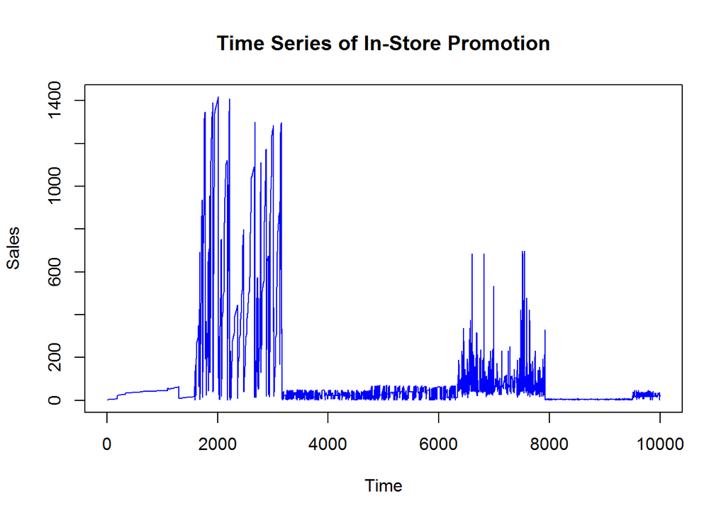

```r
promotionPlot <- function(promotionType){
promotion <- subset(ProductSales, ProductSales$promotion_type==promotionType)
promotionTS <- ts(promotion, frequency=12, start=c(2010, 1))
}

ispPlot <- promotionPlot("In-Store Promotion")
plot.ts(ispPlot[1:10000], col="blue", ylab="Sales", main="Time Series of In-Store Promotion")
```

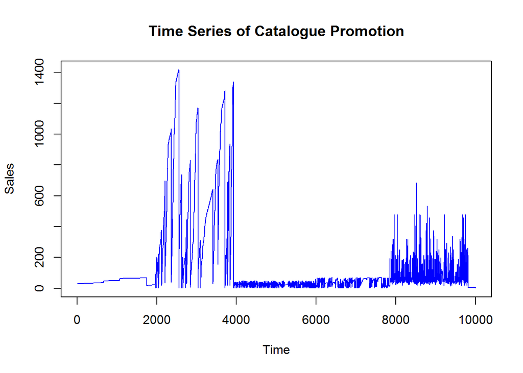

```r
cpPlot <- promotionPlot("Catalogue Promotion")
plot.ts(cpPlot[1:10000], col="blue", ylab="Sales", main="Time Series of Catalogue Promotion")
```

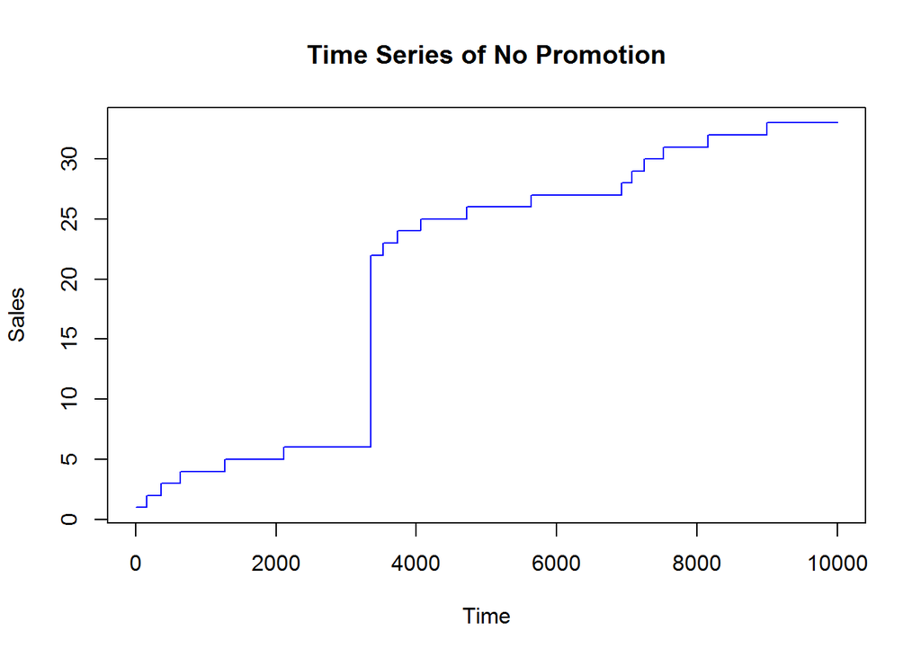

```r
npPlot <- promotionPlot("no_promotion")
plot.ts(npPlot[1:10000], col="blue", ylab="Sales", main="Time Series of No Promotion")
```

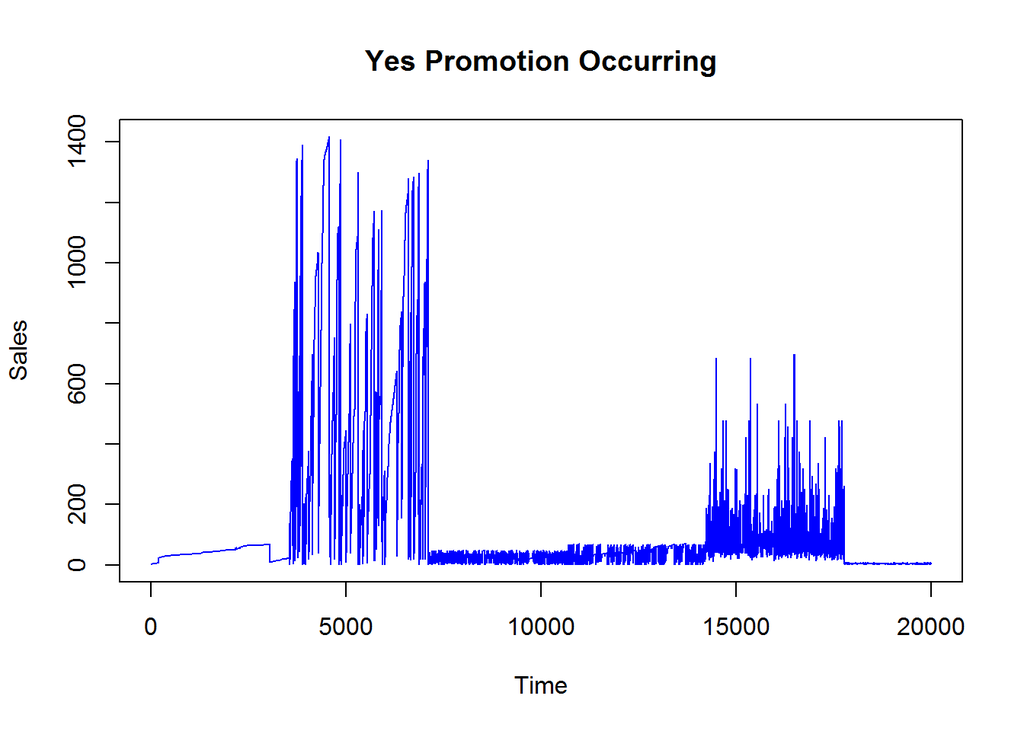

```r
isPromotion <- function(yesno){
promotion2 <- subset(ProductSales, ProductSales$promotion==yesno)
promotion2TS <- ts(promotion2, frequency=12, start=c(2010, 1))
}

yPlot <- isPromotion("Yes")
plot.ts(yPlot[1:20000], col="blue", ylab="Sales", main="Yes Promotion Occurring")
```

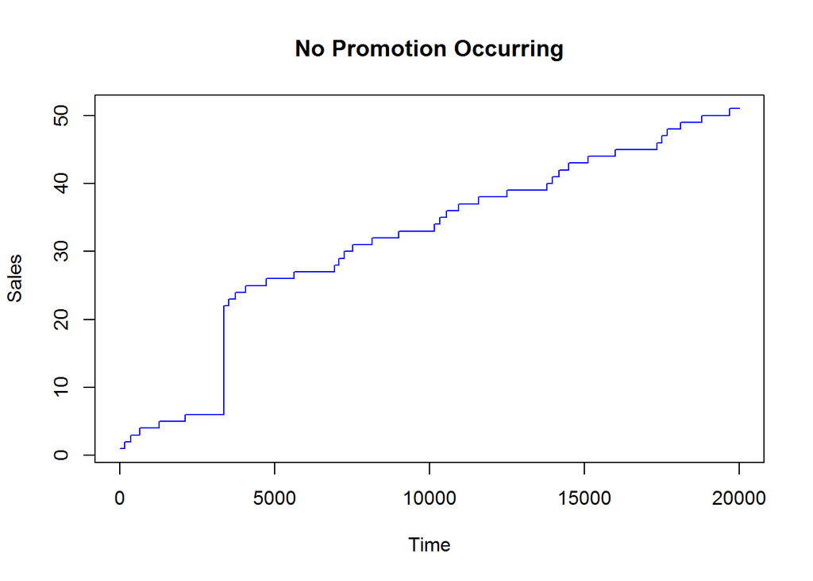

```r
nPlot <- isPromotion("No")
plot.ts(nPlot[1:20000], col="blue", ylab="Sales", main="No Promotion Occurring")
```

#### Sales Unit Analysis:

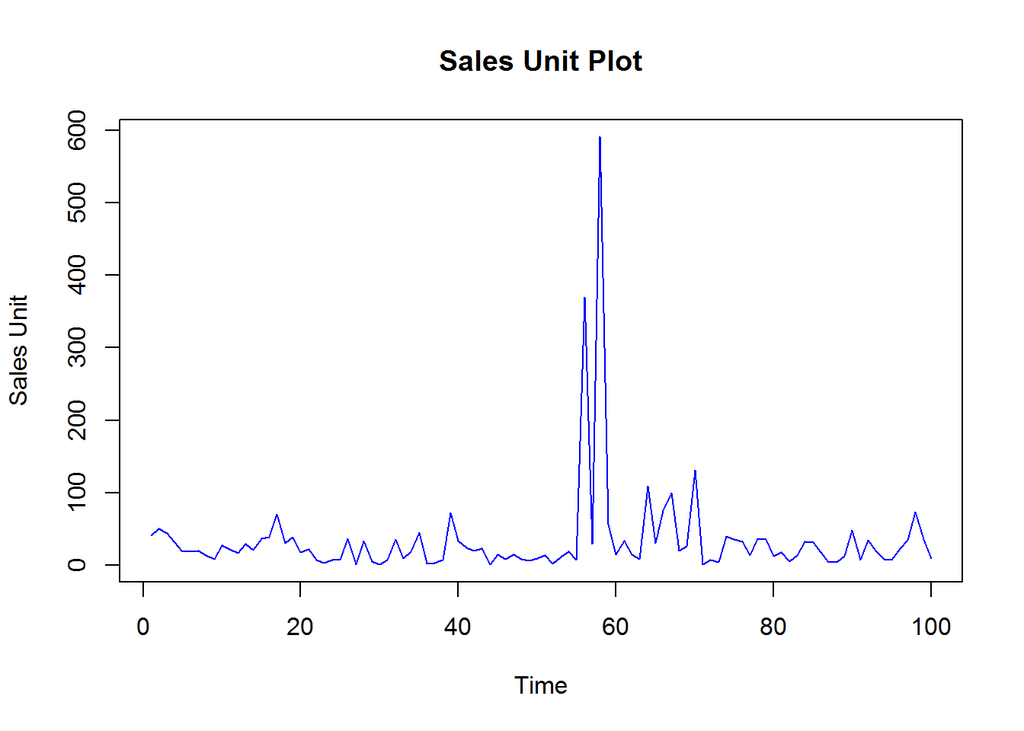

```r
SalesUnitTS <- ts(ProductSales$sales_unit, frequency=12, start=c(2010, 1))
plot.ts(SalesUnitTS[1:100], col="blue", ylab="Sales Unit", main="Sales Unit Plot")
```

### Time Series of Products:

```r
# Plot Creation Function:
obTimeSeries <- function(subcategory) {
subcategory1 <- subset(ProductSales, ProductSales$subcategory_name==subcategory)
subcategory1TS <- ts(subcategory1, frequency=12, start=c(2010, 1))
}
```

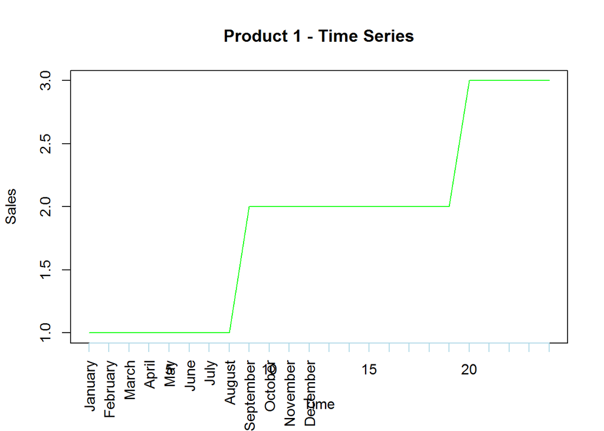

```r
plot.ts(prd1Plot[1:24], col="green", ylab="Sales", main="Product 1 - Time Series")
monthNames <- months(ISOdate(2010,1:24,1))
axis(1, at=1:24, col="lightblue", labels=monthNames, las=2)
```

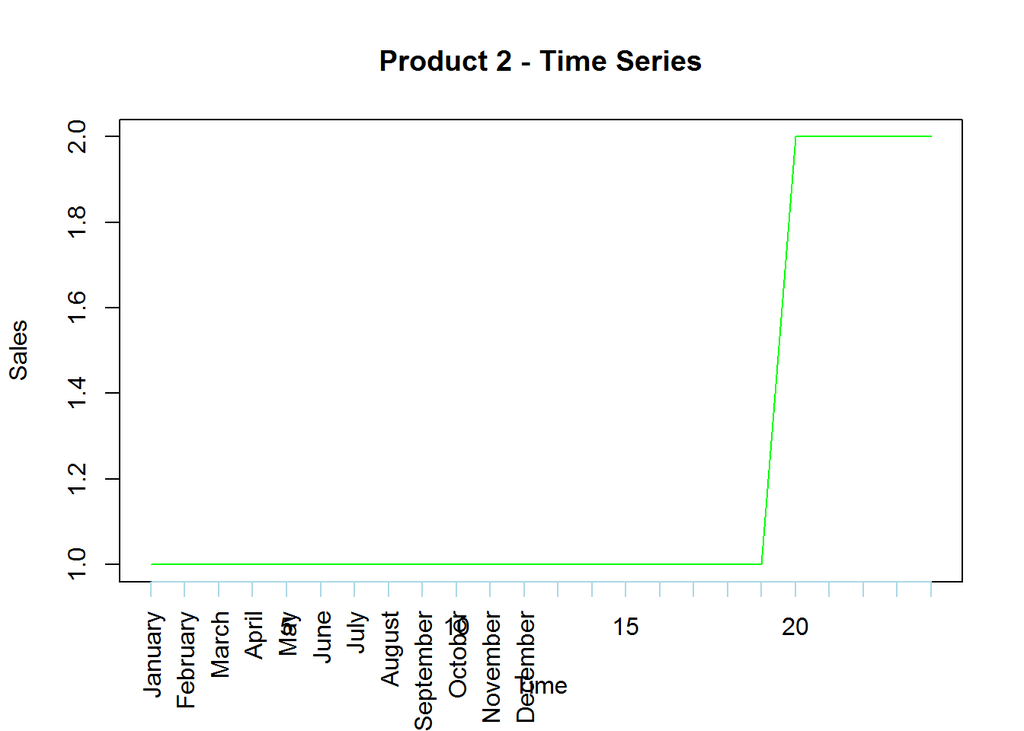

```r
plot.ts(prd2Plot[1:24], col="green", ylab="Sales", main="Product 2 - Time Series")
monthNames <- months(ISOdate(2010,1:24,1))
axis(1, at=1:24, col="lightblue", labels=monthNames, las=2)
```

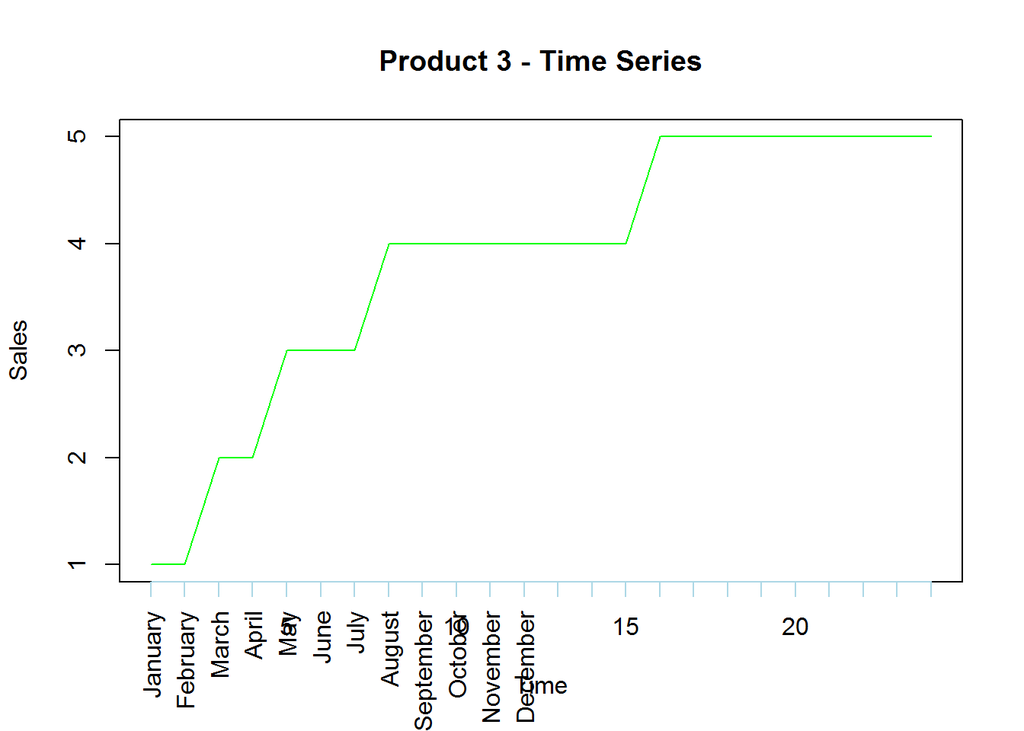

```r
plot.ts(prd3Plot[1:24], col="green", ylab="Sales", main="Product 3 - Time Series")
monthNames <- months(ISOdate(2010,1:24,1))
axis(1, at=1:24, col="lightblue", labels=monthNames, las=2)
```

### Combining Promotion & Product Time Series

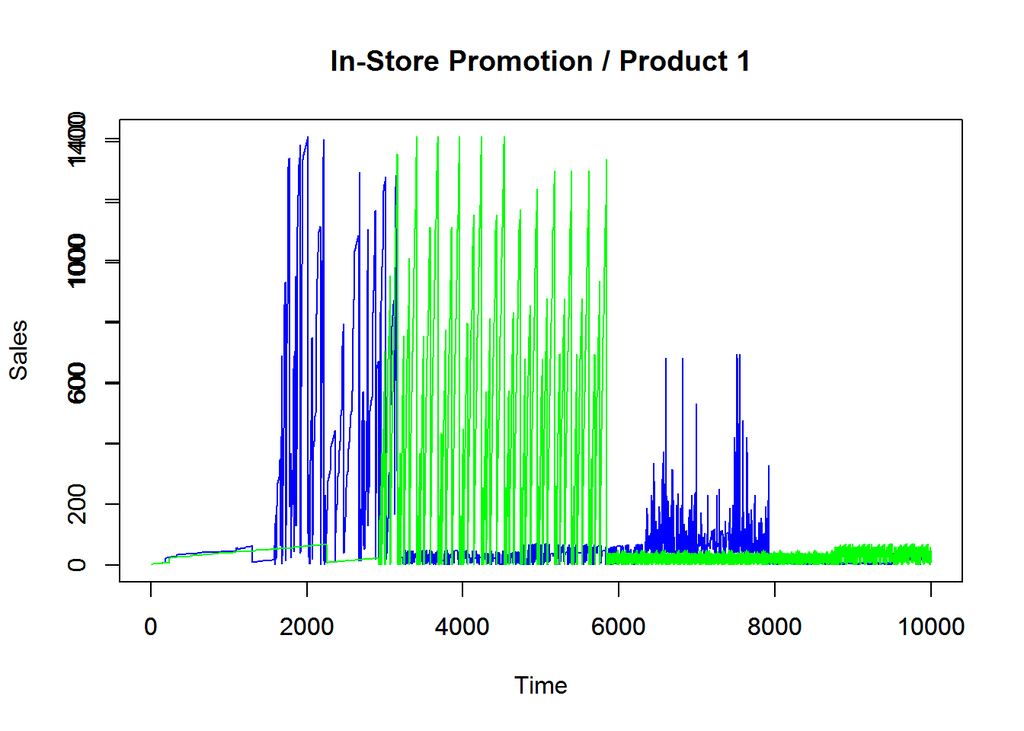

```r
plot.ts(ispPlot[1:10000], col="blue", ylab="Sales", main="In-Store Promotion / Product 1")
par(new=T)
plot.ts(prd1Plot[1:10000], col="green", ylab=" ", xlab=" ")
```

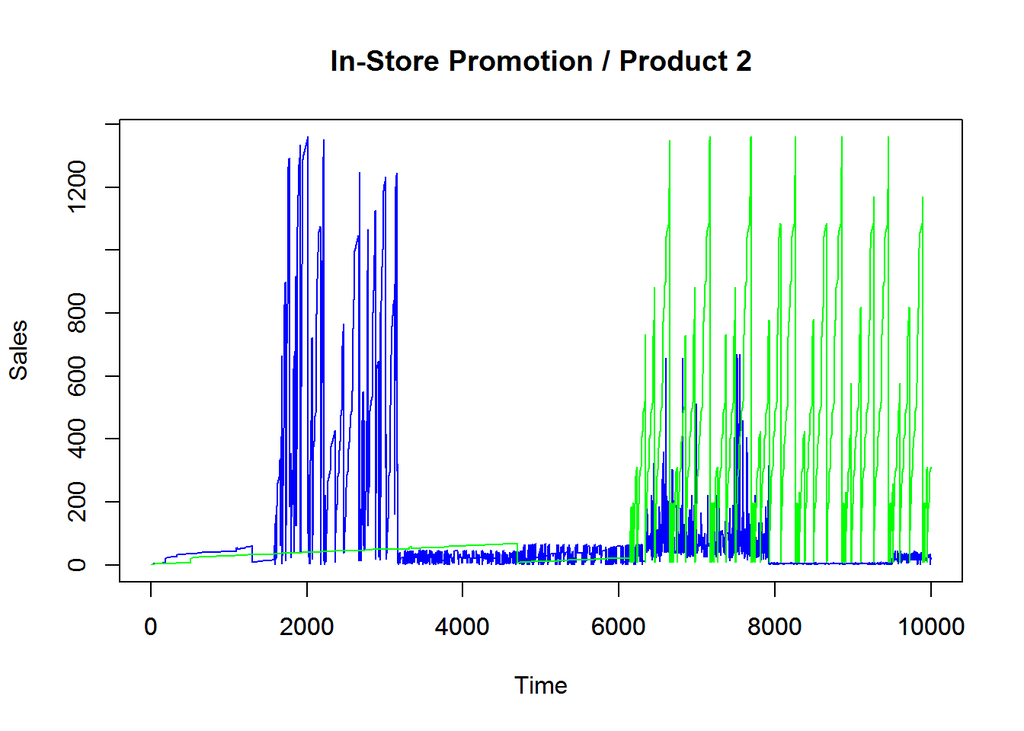

```r
par(new=F)

plot.ts(ispPlot[1:10000], yaxt='n', col="blue", ylab="Sales", main="In-Store Promotion / Product 2")
par(new=T)
plot.ts(prd2Plot[1:10000], col="green", ylab=" ", xlab=" ")
```

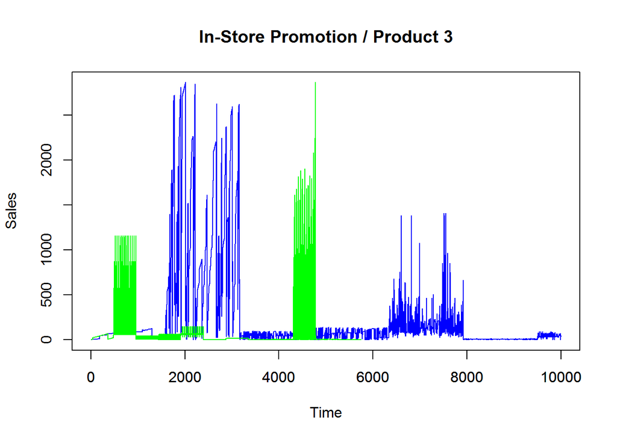

```r
par(new=F)

plot.ts(ispPlot[1:10000], yaxt='n', col="blue", ylab="Sales", main="In-Store Promotion / Product 3")
par(new=T)
plot.ts(prd3Plot[1:10000], col="green", ylab=" ", xlab=" ")
```

```r
par(new=F)
```

### Time Series Examination:

```r
StrPlot <- function(subcategory){
subcategory2 <- subset(ProductSales, ProductSales$subcategory_name==subcategory)
subcategory2TS <- ts(subcategory2, frequency=12, start=c(2010, 1))
x <- decompose(subcategory2TS)
}

adjPlot <- function(subcategory){
subcategory2 <- subset(ProductSales, ProductSales$subcategory_name==subcategory)
subcategory2TS <- ts(subcategory2, frequency=12, start=c(2010, 1))
x <- decompose(subcategory2TS)
subcategory2TSADJ <- subcategory2TS[1:24] - x$seasonal[1:24]
}

forecastPlot <- function(subcategory){
subcategory2 <- subset(ProductSales, ProductSales$subcategory_name==subcategory)
subcategory2TS <- ts(subcategory2, frequency=12, start=c(2010, 1))
subcategory2Forecasts <- HoltWinters(subcategory2TS[1:96], beta=F, gamma=F)
}
```

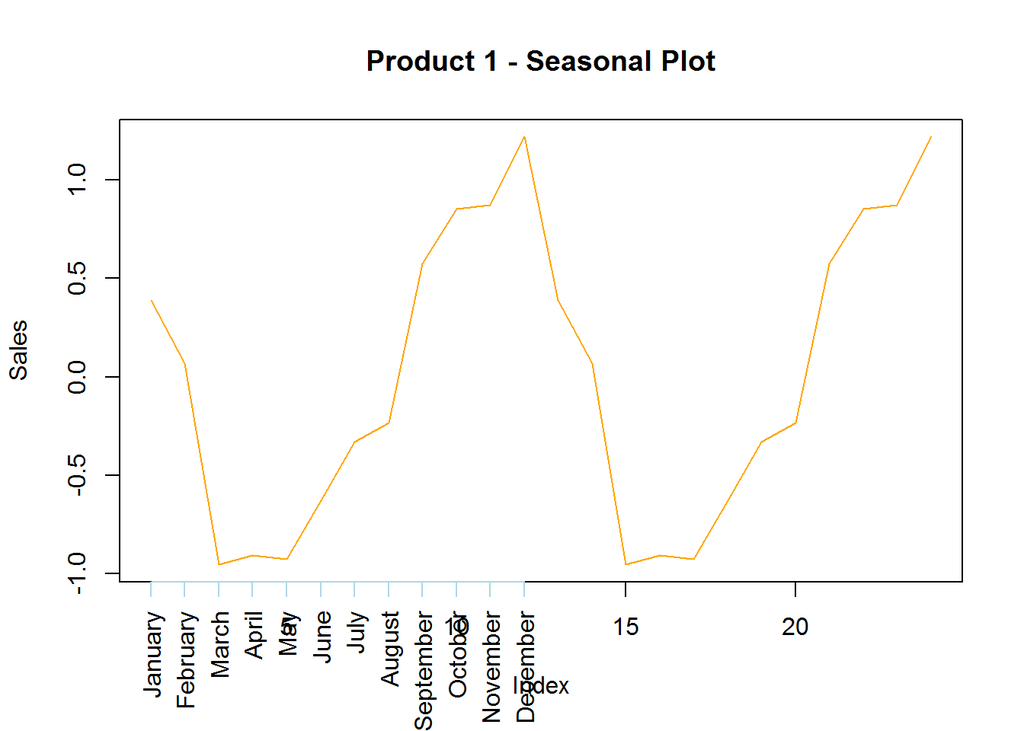

```r
plot(prd1SeaPlot$seasonal[1:24], type="line", col="orange", ylab="Sales", main="Product 1 - Seasonal Plot")
monthNames <- months(ISOdate(2008,1:12,1))
axis(1, at=1:12, col="lightblue", labels=monthNames, las=2)
```

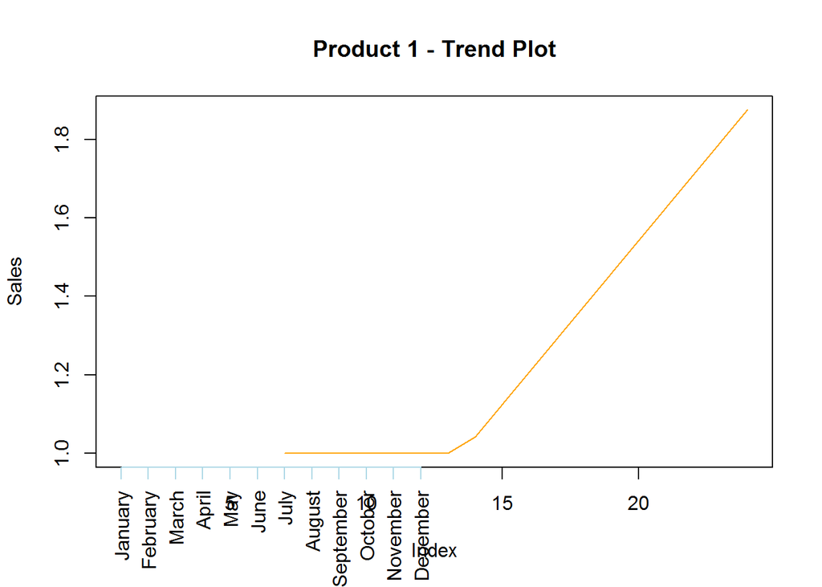

```r
plot(prd1TrPlot$trend[1:24], type="line", col="orange", ylab="Sales", main="Product 1 - Trend Plot")
monthNames <- months(ISOdate(2008,1:12,1))
axis(1, at=1:12, col="lightblue", labels=monthNames, las=2)
```

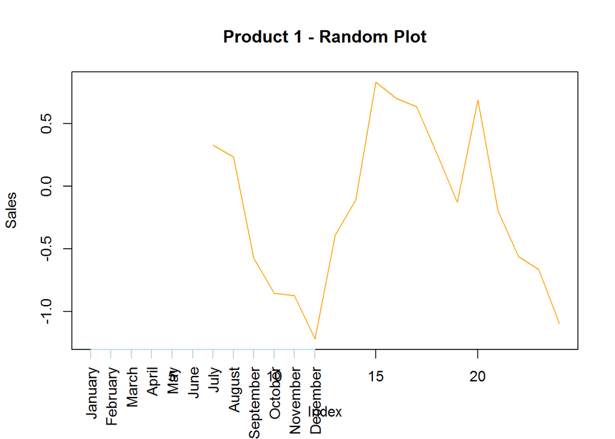

```r
plot(prd1RdPlot$random[1:24], type="line", col="orange", ylab="Sales", main="Product 1 - Random Plot")
monthNames <- months(ISOdate(2008,1:12,1))
axis(1, at=1:12, col="lightblue", labels=monthNames, las=2)
```